# Multilevel Analysis

Roma Siugzdaite

2025-05-18

**StatUa** University of Antwerp, Belgium

**Main References:** Verbeke, G. and Molenberghs, G. (2000). Linear Mixed Models for Longitudinal Data. Springer Series in Statistics. New-York: Springer. Molenberghs, G. and Verbeke, G. (2005). Models for Discrete Longitudinal Data. New York: Springer-Verlag. Fitzmaurice, G.M., Laird, N.M., and Ware J.H. (2004). Applied Longitudinal Analysis. Hoboken, New Jersey: John Wiley & Sons.

**Additional References:** Demidenko, E. (2004). Mixed Models: Theory and Applications. New York: John Wiley & Sons. Littell, R.C., Milliken, G.A., Stroup, W.W., Wolfinger, R.D., and Schabenberger, O. (2005). SAS for Mixed Models (2nd ed.). Cary: SAS Press. Verbeke, G. and Molenberghs, G. (1997). Linear Mixed Models In Practice: A SAS Oriented Approach, Lecture Notes in Statistics 126. New-York: Springer. West, B.T., Welch, K.B., and Galecki, A.T. (2007). Linear Mixed Models: A Practical Guide Using Statistical Software. Boca Raton: Chapman & Hall/CRC.

## Introduction

### Overview

Data structures: Hierarchical data Correlated data

Model Families

### Hierarchical data

**Hierarchical data** are obtained when sample is taken at multiple, hierarchically ordered, levels.

**Examples**

- Measurements taken on patients, at multiple visits after their treatment.
- Growth curves of children, animals, plants, . . .
- Survey in which all members from each of a sample of families are questioned.
- Survey in which 10 habitants from each of a sample of cities are questioned.
- Exam results from students from a sample of schools. …

These are examples of two-level data structures, but extensions to multiple levels are possible: 10 cities → In each: 5 schools → In each: 5 students → Each student given the test twice

Terminologies: Repeated Measures Longitudinal Data Multilevel Data

### Correlated data

**Example: Longitudinal Body Weight**

Consider a body weight experiment in which body weight is measured on a daily basis, for a sample of participants.

It is natural to assume body weights from different subjects to be independent from each other.

Body weights measured on the same subject are expected to be correlated.

**Should this correlation be accounted for in the analysis? If yes, how?**

**Example: Comparing BMI between Males and Females**

Suppose interest is in comparing the average BMI between males and females, based on 100 observations from each population. ⇒ Natural analysis: **Two-sample, unpaired t-test**

Suppose the 100 males and 100 females are married couples. • The BMI of spouses is likely to be correlated. ⇒ Natural analysis: **Paired t-test**

**Conclusion**

Hierarchical data structures often yield data which cannot be assumed independent.

From a statistical perspective, the key issue in modelling hierarchical data is how to account for the association between observations.

Alternative Terminology: Repeated Measures Longitudinal Data Multilevel Data Correlated Data …

### Overview of Models

Since hierarchical data are correlated, all traditional models in statistics need a counterpart for correlated data.

Many different models have been proposed in the statistical literature.

We focus on mixed models which explicitly model the various levels in the data structure.

**Cross-Sectional Data ⇒ Hierarchical Data** Linear Regression Models ⇒ Linear Mixed Models Generalized Linear Models ⇒ Generalized Linear Mixed Models Non-Linear Regression Models ⇒ Non-Linear Mixed Models

## Linear Mixed models

**Motivating Examples** The Captopril Data The Lizard Data The Paired t-Test Revisited

### The Captopril data

**Background** 15 patients with hypertension

The response of interest is the supine blood pressure, before and after treatment with CAPTOPRIL.

Research Question:

**How does treatment affect BP?**

We will be using captopril.txt data

**Codebook:** ID - patient identification number BP - numerical values of blood pleasure measurements MEAS - type of blood pleasure measurements (diastolic (1) or systolic (2)) TIME - after (2) and before (1)

```r
# you need to change the path
captopril <- read.delim("~/Documents/JOB/UANTWERPEN/FLAMES/Multilevel/Data/captopril.txt", stringsAsFactors=TRUE)
head(captopril, 3)
```

```
##   ID  BP     MEAS   TIME
## 1  1 210 systolic before
## 2  2 169 systolic before
## 3  3 187 systolic before
```

```r
tail(captopril, 3)
```

```
##    ID  BP      MEAS  TIME
## 58 13 110 diastolic after
## 59 14 103 diastolic after
## 60 15  82 diastolic after
```

Summary statistics on a sample

```r
summary(captopril)
```

```
##        ID           BP               MEAS        TIME
##  Min.   : 1   Min.   : 82.0   diastolic:30   after :30
##  1st Qu.: 4   1st Qu.:105.8   systolic :30   before:30
##  Median : 8   Median :129.5
##  Mean   : 8   Mean   :137.6
##  3rd Qu.:12   3rd Qu.:167.2
##  Max.   :15   Max.   :210.0
```

## Plot

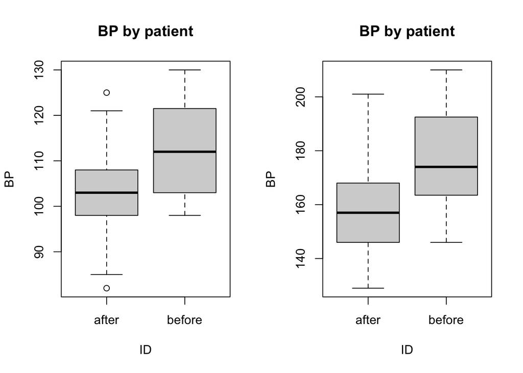

```r
data1 <- subset(captopril, MEAS == "diastolic")
data2 <- subset(captopril, MEAS == "systolic")

par(mfrow = c(1, 2))
plot(data1$TIME,data1$BP,type="p",xlab="ID",
     ylab="BP",main="BP by patient")
plot(data2$TIME,data2$BP,type="p",xlab="ID",
     ylab="BP",main="BP by patient")
```

What is the first impression?

Ploting changes per type and time:

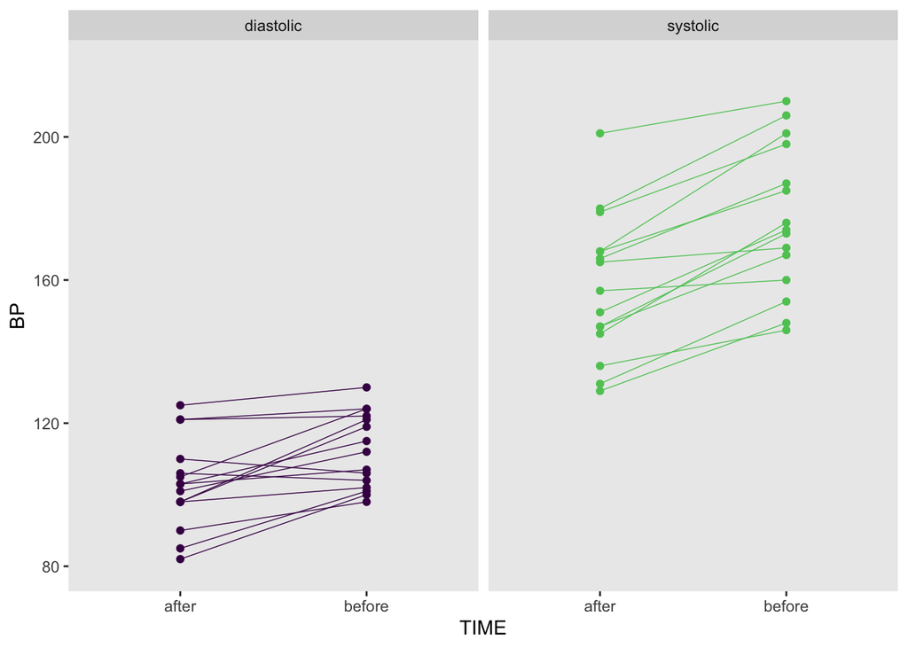

```r
library(ggplot2)
ggplot(captopril, aes(x = TIME, y = BP, color = factor(MEAS))) +
  geom_line(aes(group = ID), linewidth = 1/4) +
  geom_point()+
  scale_color_viridis_d(end = .75) +
  coord_cartesian(ylim = c(80, 220)) +
  theme(legend.position = "none", panel.grid = element_blank()) +
  facet_wrap(~ MEAS)
```

Consider an analysis of diastolic BP:

Average (mm Hg) Diastolic Before: 112.333 Diastolic After: 103.067

There is an average decrease of **more than 9 mm HG.**

The classical analysis of paired data is based on comparisons within subjects:

∆i =Yi1 −Yi2, i=1,2,…,15

positive ∆i ⇒ corresponds to a decrease of the BP negative ∆i ⇒ corresponds to an increase of the BP

## Paired T-test

Testing for treatment effect is now equivalent to testing whether the average difference μ∆ equals zero.

R output

```r
library(stats)
## paired t-test
after <- subset(data1, TIME == "after")
before <- subset(data1, TIME == "before")
t.test(after$BP, before$BP, paired = TRUE)
```

```
##
##  Paired t-test
##
## data:  after$BP and before$BP
## t = -4.1662, df = 14, p-value = 0.0009511
## alternative hypothesis: true mean difference is not equal to 0
## 95 percent confidence interval:
##  -14.037215  -4.496118
## sample estimates:
## mean difference
##       -9.266667
```

```r
## unpaired t-test
t.test(after$BP, before$BP, paired = FALSE)
```

```
##
##  Welch Two Sample t-test
##
## data:  after$BP and before$BP
## t = -2.1952, df = 27.126, p-value = 0.03689
## alternative hypothesis: true difference in means is not equal to 0
## 95 percent confidence interval:
##  -17.9264010  -0.6069323
## sample estimates:
## mean of x mean of y
##  103.0667  112.3333
```

### Paired vs. Unpaired t-Test

Comparing results from unpaired and paired analysis: Unpaired. Paired Estimated Difference. d̄ 9.2667 9.2666 Std. Err. of Estimated Difference se(d) 4.2214 2.2243 Test Statistic Value t 2.20 4.17 p-value p 0.0366 0.0010 ̄

Although both tests lead to a significant result, there is a serious difference in p-values.

⇒ **Ignoring the paired nature of the data can lead to wrong conclusions!**

### Conclusion

**The correlation cannot be ignored in the analysis.**

In the paired t-test, the correlation problem is circumvented by taking within-subject differences,

∆i =Yi1 −Yi2, i=1,2,…,15.

How can this be extended to: multiple measurements per subject? include covariate information? multiple levels in the data structure?

Make a linear model:

```r
library(sjPlot)
model <- lm(BP~ MEAS + TIME , data = captopril)
summary(model)
```

```
##
## Call:
## lm(formula = BP ~ MEAS + TIME, data = captopril)
##
## Residuals:
##     Min      1Q  Median      3Q     Max
## -31.417 -12.917  -0.133   9.250  40.583
##
## Coefficients:
##              Estimate Std. Error t value Pr(>|t|)
## (Intercept)   100.650      3.701  27.195  < 2e-16 ***
## MEASsystolic   59.767      4.274  13.985  < 2e-16 ***
## TIMEbefore     14.100      4.274   3.299  0.00167 **
## ---
## Signif. codes:  0 '***' 0.001 '**' 0.01 '*' 0.05 '.' 0.1 ' ' 1
##
## Residual standard error: 16.55 on 57 degrees of freedom
## Multiple R-squared:  0.7837, Adjusted R-squared:  0.7761
## F-statistic: 103.2 on 2 and 57 DF,  p-value: < 2.2e-16
```

```r
anova(model)
```

```
## Analysis of Variance Table
##
## Response: BP
##           Df Sum Sq Mean Sq F value    Pr(>F)
## MEAS       1  53581   53581 195.580 < 2.2e-16 ***
## TIME       1   2982    2982  10.885  0.001674 **
## Residuals 57  15616     274
## ---
## Signif. codes:  0 '***' 0.001 '**' 0.01 '*' 0.05 '.' 0.1 ' ' 1
```

```r
tab <- tab_model(model)
tab
```

|  | BP |  |  |
| --- | --- | --- | --- |
| Predictors | Estimates | CI | p |
| (Intercept) | 100.65 | 93.24 – 108.06 | **<0.001** |
| MEAS [systolic] | 59.77 | 51.21 – 68.32 | **<0.001** |
| TIME [before] | 14.10 | 5.54 – 22.66 | **0.002** |
| Observations | 60 |  |  |
| R<sup>2</sup> / R<sup>2</sup> adjusted | 0.784 / 0.776 |  |  |

```r
library(lme4)
model2 <- lmer(BP~ MEAS + TIME + (1|ID) , data = captopril)
summary(model2)
```

```
## Linear mixed model fit by REML ['lmerMod']
## Formula: BP ~ MEAS + TIME + (1 | ID)
##    Data: captopril
##
## REML criterion at convergence: 465.2
##
## Scaled residuals:
##      Min       1Q   Median       3Q      Max
## -1.74763 -0.63515 -0.03632  0.54764  1.82298
##
## Random effects:
##  Groups   Name        Variance Std.Dev.
##  ID       (Intercept) 171.0    13.08
##  Residual             105.9    10.29
## Number of obs: 60, groups:  ID, 15
##
## Fixed effects:
##              Estimate Std. Error t value
## (Intercept)   100.650      4.086  24.631
## MEASsystolic   59.767      2.657  22.491
## TIMEbefore     14.100      2.657   5.306
##
## Correlation of Fixed Effects:
##             (Intr) MEASsy
## MEASsystolc -0.325
## TIMEbefore  -0.325  0.000
```

```r
anova(model2)
```

```
## Analysis of Variance Table
##      npar Sum Sq Mean Sq F value
## MEAS    1  53581   53581 505.836
## TIME    1   2982    2982  28.153
```

```r
tab <- tab_model(model2)
tab
```

|  | BP |  |  |
| --- | --- | --- | --- |
| Predictors | Estimates | CI | p |
| (Intercept) | 100.65 | 92.46 – 108.84 | **<0.001** |
| MEAS [systolic] | 59.77 | 54.44 – 65.09 | **<0.001** |
| TIME [before] | 14.10 | 8.77 – 19.43 | **<0.001** |
| Random Effects |  |  |  |
| σ<sup>2</sup> | 105.93 |  |  |
| τ<sub>00</sub> <sub>ID</sub> | 171.03 |  |  |
| ICC | 0.62 |  |  |
| N <sub>ID</sub> | 15 |  |  |
| Observations | 60 |  |  |
| Marginal R<sup>2</sup> / Conditional R<sup>2</sup> | 0.776 / 0.914 |  |  |

## Lizard data

Background

Data on 102 lizards

Response of Interest: number of dorsal shells

Research Question:

**Is the number of dorsal shells gender-related?**

Codebook: MOTHC: Mother code SEX: 1 - male, 2 female DORS: number of dorsal shells

```r
lizard <- read.delim("~/Documents/JOB/UANTWERPEN/FLAMES/Multilevel/Data/lizard.txt")
head(lizard)
```

```
##   MOTHC SEX DORS
## 1     2   1   37
## 2     2   1   39
## 3     2   1   35
## 4     2   2   35
## 5     3   1   35
## 6     4   1   37
```

```r
lizard$SEX <- as.factor(lizard$SEX)
```

T-test unpaired

```r
t.test(DORS ~ SEX, data = lizard)
```

```
##
##  Welch Two Sample t-test
##
## data:  DORS by SEX
## t = 1.6338, df = 93.311, p-value = 0.1057
## alternative hypothesis: true difference in means between group 1 and group 2 is not equal to 0
## 95 percent confidence interval:
##  -0.1450793  1.4923016
## sample estimates:
## mean in group 1 mean in group 2
##        35.39583        34.72222
```

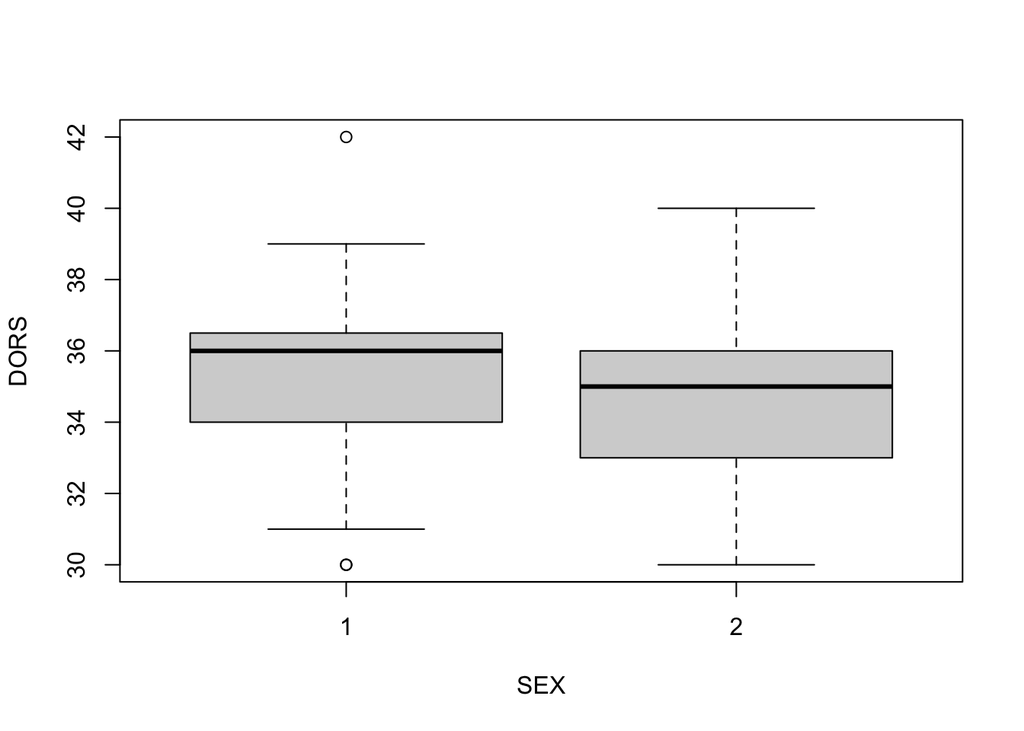

```r
plot(DORS ~ SEX, data = lizard, var.equal = FALSE)
```

A typical aspect of the data is that some animals have the same mother.

We have 102 lizards from 29 mothers. Mother effects might be present.

⇒ **Hence, a comparison between male and female animals should be based on within-mother comparisons.**

### Within mother comparison

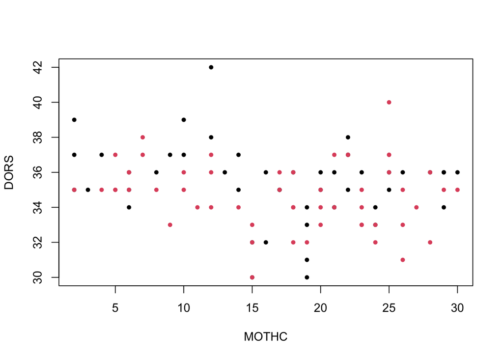

```r
plot(DORS~ MOTHC, col = SEX, data = lizard, pch=20)
```

much between-mother variability

often, males (considerably) higher than females

in cases where females higher than males, small differences

### Remarks

The non-significant t-test result may be due to the between-mother variability. This is an example of clustered data.

⇒ Observations are **clustered** within mothers.

Measurements within mothers can be expected to be more alike than measurements from different mothers.

We expect **correlated observations within mothers and independent observations between mothers.**

How can we correct for differences between mothers?

### Two way ANOVA

An obvious first choice to test for a ‘sex’ effect, correcting for ‘mother’ effects, is a two-way ANOVA with factors ‘sex’ and ‘mother’.

The mother effect then represents the variability between mothers.

Let Yij be the jth measurement on the ith mother, and let xij be 0 for males and 1 for females. The model then equals:

Yij =μ+αi +βxij +εij.

Parameter interpretation:

Overall mean: μ Gender effect: β is the parameter of interest, the average difference between males and females. Mother effect: αi

Since the model is overparameterized, restrictions are needed, e.g., Xαi =0.

Residual distribution: εij ∼ N (0, σ2res ).

```r
# MOTHERS AS A GROUPS - FACTORS
lizard$MOTHC <- as.factor(lizard$MOTHC)

# if ignore the mothers effect
# With the t-test, ignoring the mother effect
model <- lm(DORS ~ SEX, data=lizard)
summary(model)
```

```
##
## Call:
## lm(formula = DORS ~ SEX, data = lizard)
##
## Residuals:
##     Min      1Q  Median      3Q     Max
## -5.3958 -1.3958  0.2778  1.2778  6.6042
##
## Coefficients:
##             Estimate Std. Error t value Pr(>|t|)
## (Intercept)  35.3958     0.2973 119.050   <2e-16 ***
## SEX2         -0.6736     0.4086  -1.648    0.102
## ---
## Signif. codes:  0 '***' 0.001 '**' 0.01 '*' 0.05 '.' 0.1 ' ' 1
##
## Residual standard error: 2.06 on 100 degrees of freedom
## Multiple R-squared:  0.02646,    Adjusted R-squared:  0.01672
## F-statistic: 2.717 on 1 and 100 DF,  p-value: 0.1024
```

```r
# Adding mother's effect
library(car)
model <- lm(DORS ~ SEX + MOTHC, data=lizard)
resultsAnova<-summary(model)
tab <- tab_model(resultsAnova)
tab
```

|  | DORS |  |  |
| --- | --- | --- | --- |
| Predictors | Estimates | CI | p |
| (Intercept) | 36.73 | 35.20 – 38.26 | **<0.001** |
| SEX [2] | -0.92 | -1.60 – -0.24 | **0.009** |
| MOTHC [3] | -1.73 | -5.13 – 1.67 | 0.314 |
| MOTHC [4] | -0.27 | -2.91 – 2.37 | 0.838 |
| MOTHC [5] | -0.15 | -2.52 – 2.23 | 0.902 |
| MOTHC [6] | -0.94 | -2.91 – 1.03 | 0.346 |
| MOTHC [7] | 1.69 | -0.99 – 4.37 | 0.214 |
| MOTHC [8] | -0.77 | -3.41 – 1.87 | 0.562 |
| MOTHC [9] | -1.27 | -3.91 – 1.37 | 0.340 |
| MOTHC [10] | 0.48 | -1.68 – 2.63 | 0.659 |
| MOTHC [11] | -1.81 | -5.25 – 1.62 | 0.296 |
| MOTHC [12] | 1.22 | -0.83 – 3.27 | 0.240 |
| MOTHC [13] | -0.73 | -4.13 – 2.67 | 0.671 |
| MOTHC [14] | -1.09 | -3.41 – 1.23 | 0.352 |
| MOTHC [15] | -4.78 | -6.83 – -2.73 | **<0.001** |
| MOTHC [16] | -2.73 | -5.37 – -0.09 | **0.043** |
| MOTHC [17] | -1.02 | -3.18 – 1.13 | 0.348 |
| MOTHC [18] | -1.60 | -3.67 – 0.48 | 0.129 |
| MOTHC [19] | -4.55 | -6.58 – -2.51 | **<0.001** |
| MOTHC [20] | -1.58 | -3.63 – 0.47 | 0.129 |
| MOTHC [21] | -1.36 | -3.40 – 0.68 | 0.188 |
| MOTHC [22] | 0.41 | -1.55 – 2.37 | 0.679 |
| MOTHC [23] | -1.80 | -3.87 – 0.28 | 0.088 |
| MOTHC [24] | -3.27 | -5.43 – -1.12 | **0.003** |
| MOTHC [25] | 0.71 | -1.27 – 2.70 | 0.475 |
| MOTHC [26] | -2.29 | -4.47 – -0.12 | **0.039** |
| MOTHC [27] | -1.81 | -5.25 – 1.62 | 0.296 |
| MOTHC [28] | -1.45 | -3.79 – 0.89 | 0.220 |
| MOTHC [29] | -1.25 | -3.40 – 0.90 | 0.250 |
| MOTHC [30] | -0.77 | -3.41 – 1.87 | 0.562 |
| Observations | 102 |  |  |
| R<sup>2</sup> / R<sup>2</sup> adjusted | 0.616 / 0.461 |  |  |

```r
resultsType3<-Anova(lm(DORS ~ SEX + MOTHC, data=lizard),type=3)
resultsType3
```

```
## Anova Table (Type III tests)
##
## Response: DORS
##             Sum Sq Df   F value    Pr(>F)
## (Intercept) 5329.3  1 2292.5054 < 2.2e-16 ***
## SEX           16.7  1    7.1948  0.009062 **
## MOTHC        256.9 28    3.9474 1.421e-06 ***
## Residuals    167.4 72
## ---
## Signif. codes:  0 '***' 0.001 '**' 0.01 '*' 0.05 '.' 0.1 ' ' 1
```

```r
overallTest<-round(c(resultsAnova$fstatistic,
    pf(resultsAnova$fstatistic[1],
    resultsAnova$fstatistic[2],
    resultsAnova$fstatistic[3],
    lower.tail=FALSE)),digits=3)
overallTest
```

```
##  value  numdf  dendf  value
##  3.982 29.000 72.000  0.000
```

```r
type3Test <- resultsType3[c(2,3),]
type3Test
```

```
## Anova Table (Type III tests)
##
## Response: DORS
##        Sum Sq Df F value    Pr(>F)
## SEX    16.725  1  7.1948  0.009062 **
## MOTHC 256.938 28  3.9474 1.421e-06 ***
## ---
## Signif. codes:  0 '***' 0.001 '**' 0.01 '*' 0.05 '.' 0.1 ' ' 1
```

Note the highly significant mother effect.

We now also obtain a significant gender effect.

Many degrees of freedom are spent to the estimation of the mother effect, which is not even of interest.

```r
#Adding mothers as a random effect
library(lme4)
resultsMixed <- lmer(DORS ~ SEX + (1| MOTHC), data=lizard)
summary(resultsMixed)
```

```
## Linear mixed model fit by REML ['lmerMod']
## Formula: DORS ~ SEX + (1 | MOTHC)
##    Data: lizard
##
## REML criterion at convergence: 407.9
##
## Scaled residuals:
##      Min       1Q   Median       3Q      Max
## -1.89104 -0.48986  0.05528  0.55686  3.05889
##
## Random effects:
##  Groups   Name        Variance Std.Dev.
##  MOTHC    (Intercept) 1.78     1.334
##  Residual             2.25     1.500
## Number of obs: 102, groups:  MOTHC, 29
##
## Fixed effects:
##             Estimate Std. Error t value
## (Intercept)  35.4904     0.3422 103.707
## SEX2         -0.8289     0.3220  -2.574
##
## Correlation of Fixed Effects:
##      (Intr)
## SEX2 -0.497
```

```r
anova(resultsMixed)
```

```
## Analysis of Variance Table
##     npar Sum Sq Mean Sq F value
## SEX    1 14.909  14.909  6.6266
```

```r
tab <- tab_model(resultsMixed)
tab
```

|  | DORS |  |  |
| --- | --- | --- | --- |
| Predictors | Estimates | CI | p |
| (Intercept) | 35.49 | 34.81 – 36.17 | **<0.001** |
| SEX [2] | -0.83 | -1.47 – -0.19 | **0.012** |
| Random Effects |  |  |  |
| σ<sup>2</sup> | 2.25 |  |  |
| τ<sub>00</sub> <sub>MOTHC</sub> | 1.78 |  |  |
| ICC | 0.44 |  |  |
| N <sub>MOTHC</sub> | 29 |  |  |
| Observations | 102 |  |  |
| Marginal R<sup>2</sup> / Conditional R<sup>2</sup> | 0.041 / 0.465 |  |  |

```r
library(lme4)
resultsMixed <- lmer(DORS ~ SEX + (1|MOTHC), data=lizard)
summary(resultsMixed)
```

```
## Linear mixed model fit by REML ['lmerMod']
## Formula: DORS ~ SEX + (1 | MOTHC)
##    Data: lizard
##
## REML criterion at convergence: 407.9
##
## Scaled residuals:
##      Min       1Q   Median       3Q      Max
## -1.89104 -0.48986  0.05528  0.55686  3.05889
##
## Random effects:
##  Groups   Name        Variance Std.Dev.
##  MOTHC    (Intercept) 1.78     1.334
##  Residual             2.25     1.500
## Number of obs: 102, groups:  MOTHC, 29
##
## Fixed effects:
##             Estimate Std. Error t value
## (Intercept)  35.4904     0.3422 103.707
## SEX2         -0.8289     0.3220  -2.574
##
## Correlation of Fixed Effects:
##      (Intr)
## SEX2 -0.497
```

```r
anova(resultsMixed)
```

```
## Analysis of Variance Table
##     npar Sum Sq Mean Sq F value
## SEX    1 14.909  14.909  6.6266
```

```r
tab <- tab_model(resultsMixed)
tab
```

|  | DORS |  |  |
| --- | --- | --- | --- |
| Predictors | Estimates | CI | p |
| (Intercept) | 35.49 | 34.81 – 36.17 | **<0.001** |
| SEX [2] | -0.83 | -1.47 – -0.19 | **0.012** |
| Random Effects |  |  |  |
| σ<sup>2</sup> | 2.25 |  |  |
| τ<sub>00</sub> <sub>MOTHC</sub> | 1.78 |  |  |
| ICC | 0.44 |  |  |
| N <sub>MOTHC</sub> | 29 |  |  |
| Observations | 102 |  |  |
| Marginal R<sup>2</sup> / Conditional R<sup>2</sup> | 0.041 / 0.465 |  |  |

```r
library(nlme)
# Parameter estimates:
resultMixed<-summary(lme(DORS~SEX , random = ~1|MOTHC, data = lizard))
fixEffSolution<-resultMixed$tTable
fixEffSolution
```

```
##                  Value Std.Error DF    t-value      p-value
## (Intercept) 35.4903631 0.3422179 72 103.706928 3.932505e-80
## SEX2        -0.8289251 0.3220116 72  -2.574209 1.210397e-02
```

```r
# Type 3 tests of fixed effects:

type3Results <- anova.lme(resultMixed,type="marginal")
type3Results # to see in the environment
```

```
##             numDF denDF   F-value p-value
## (Intercept)     1    72 10755.127  <.0001
## SEX             1    72     6.627  0.0121
```

```r
# t-test
t.test(DORS ~ SEX, data = lizard)
```

```
##
##  Welch Two Sample t-test
##
## data:  DORS by SEX
## t = 1.6338, df = 93.311, p-value = 0.1057
## alternative hypothesis: true difference in means between group 1 and group 2 is not equal to 0
## 95 percent confidence interval:
##  -0.1450793  1.4923016
## sample estimates:
## mean in group 1 mean in group 2
##        35.39583        34.72222
```

```r
# Covariance parameter estimates

covParEst<-VarCorr(resultMixed)
rownames(covParEst) <-c("MOTHC","Residual")
covParEst
```

```
## MOTHC = pdLogChol(1)
##          Variance StdDev
## MOTHC    1.780446 1.334334
## Residual 2.249915 1.499972
```

```r
# OR

modelmixed <- lmer(DORS~SEX + (1|MOTHC), data = lizard)
modelmixed
```

```
## Linear mixed model fit by REML ['lmerMod']
## Formula: DORS ~ SEX + (1 | MOTHC)
##    Data: lizard
## REML criterion at convergence: 407.8786
## Random effects:
##  Groups   Name        Std.Dev.
##  MOTHC    (Intercept) 1.334
##  Residual             1.500
## Number of obs: 102, groups:  MOTHC, 29
## Fixed Effects:
## (Intercept)         SEX2
##     35.4904      -0.8289
```

```r
tab <- tab_model(modelmixed)
tab
```

|  | DORS |  |  |
| --- | --- | --- | --- |
| Predictors | Estimates | CI | p |
| (Intercept) | 35.49 | 34.81 – 36.17 | **<0.001** |
| SEX [2] | -0.83 | -1.47 – -0.19 | **0.012** |
| Random Effects |  |  |  |
| σ<sup>2</sup> | 2.25 |  |  |
| τ<sub>00</sub> <sub>MOTHC</sub> | 1.78 |  |  |
| ICC | 0.44 |  |  |
| N <sub>MOTHC</sub> | 29 |  |  |
| Observations | 102 |  |  |
| Marginal R<sup>2</sup> / Conditional R<sup>2</sup> | 0.041 / 0.465 |  |  |

ICC = 0.44 variance explained when you correct for gender

```r
modelmixed <- lmer(DORS ~ (1|MOTHC), data = lizard)
modelmixed
```

```
## Linear mixed model fit by REML ['lmerMod']
## Formula: DORS ~ (1 | MOTHC)
##    Data: lizard
## REML criterion at convergence: 413.8189
## Random effects:
##  Groups   Name        Std.Dev.
##  MOTHC    (Intercept) 1.297
##  Residual             1.560
## Number of obs: 102, groups:  MOTHC, 29
## Fixed Effects:
## (Intercept)
##       35.05
```

```r
tab <- tab_model(modelmixed)
tab
```

|  | DORS |  |  |
| --- | --- | --- | --- |
| Predictors | Estimates | CI | p |
| (Intercept) | 35.05 | 34.47 – 35.64 | **<0.001** |
| Random Effects |  |  |  |
| σ<sup>2</sup> | 2.43 |  |  |
| τ<sub>00</sub> <sub>MOTHC</sub> | 1.68 |  |  |
| ICC | 0.41 |  |  |
| N <sub>MOTHC</sub> | 29 |  |  |
| Observations | 102 |  |  |
| Marginal R<sup>2</sup> / Conditional R<sup>2</sup> | 0.000 / 0.409 |  |  |

ICC 0.41 variance explained without taking into account gender